# R Notebook

```r
library(tidyverse)
library(janitor)
library(infer)
books <- read_csv("data/books.csv")
books_tidy <- books %>%
  clean_names() %>%
  filter(!is.na(average_rating)) %>%
  rename(num_pages = number_num_pages) %>%
  glimpse()
```

```
Rows: 10,999
Columns: 10
$ book_id            <dbl> 1, 2, 3, 4, 5, 8, 9, 10, 12, 13, 14, 16, 18, 21, 22, 23…
$ title              <chr> "Harry Potter and the Half-Blood Prince (Harry Potter  …
$ authors            <chr> "J.K. Rowling-Mary GrandPré", "J.K. Rowling-Mary GrandP…
$ average_rating     <dbl> 4.56, 4.49, 4.47, 4.41, 4.55, 4.78, 3.69, 4.73, 4.38, 4…
$ isbn               <chr> "0439785960", "0439358078", "0439554934", "0439554896",…
$ isbn13             <chr> "9780439785969", "9780439358071", "9780439554930", "978…
$ language_code      <chr> "eng", "eng", "eng", "eng", "eng", "eng", "en-US", "eng…
$ num_pages          <dbl> 652, 870, 320, 352, 435, 2690, 152, 3342, 815, 815, 215…
$ ratings_count      <dbl> 1944099, 1996446, 5629932, 6267, 2149872, 38872, 18, 27…
$ text_reviews_count <dbl> 26249, 27613, 70390, 272, 33964, 154, 1, 820, 258, 3954…
```

Plot the distribution of the “average rating”

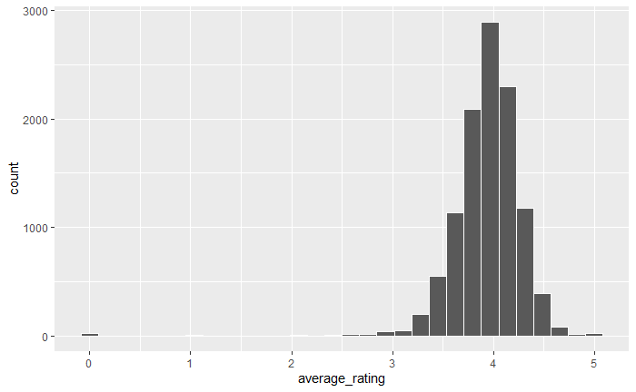

```r
books_tidy %>%
  ggplot(aes(average_rating)) +
  geom_histogram(col = "white")
```

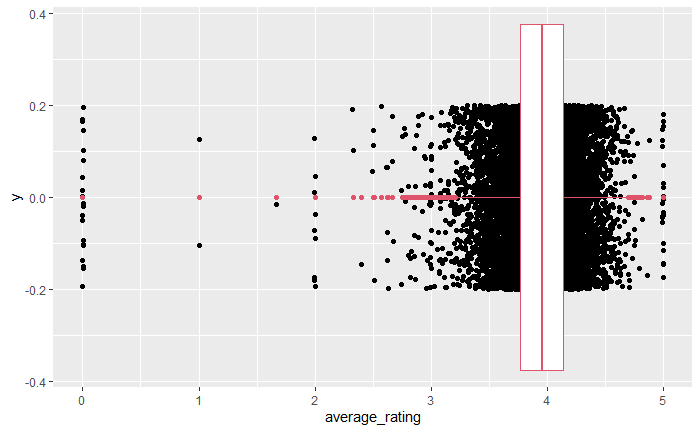

```r
books_tidy %>%
  ggplot(aes(average_rating)) +
  geom_jitter(aes(y = 0), height = 0.2) +
  geom_boxplot(colour = 2)
```

The data we have is from 2020 GoodReads data base.

We are going to test to see if: - the 2020 average rating is different from the 2016 average

```r
observed_stat <- books_tidy %>%
  summarise(mean_rating = mean(average_rating))

observed_stat
```

| mean_rating |
| --- |
| 3.937568 |

```r
NA
```

The 2016 average is 3.93 The 2020 average is 3.937568

Set up two *competing* hypotheses

*null* hypothesis : H0 $H_0$ Framed as the skeptical position … the hypothesis of: - no difference - no change - things are the same

*alternative* hypothesis H1 $H_1$ or Ha $H_a$ … the hypothesis of difference

*null*

The average rating from 2020 is *the same* as the average rating from 2016

*alternative*

The average rating from 2020 is *different* from the average rating from 2016

Our two hypotheses must be - mutually exclusive - exhaustive

$$H_0: \mu_{average\ rating} = 3.93$$
$$H_1: \mu_{average\ rating} \neq 3.93$$

Greek letters usually used to represent population parameters.

$$\mu = population\ mean\\
\pi = population\ proportion$$

Latin letters usually used to represent sample estimates

Is the difference between 2016 and 2020 average ratings significantly different?

## Steps of a hypothesis test:

> Step 1

*Before* we look at the data

decide on our *significance level* (alpha level): set a threshold for what counts as significant

Sets the error rate, it will dictate how often we wrongly declare significance - so with alpha of 0.05 we can expect to wrongly reject H0 1 in 20 times

By convention, at least very often, the most commonalpha level is *0.05*

> Step 2

Calculate the statistic from the sample in this case it’s the mean

> Step 3

create the sampling distribution - we’ll do this by bootstrapping

*very important*

when we creat the sampling distribution we *assume that H0 is true*

> Step 4

compare our calculated statistic with the sampling distribution If the calculated is stat is far enough into the tail of our null dist … we call it significant … *p-value*

> Step 5

If the p-value is < alpha we *reject* H0 If the p-value is not < alpha we *do not reject* H0

If the p-value is < alpha we *reject* H0 find evidence in support of our H1

If the p-value is not < alpha we *do not reject* H0 failed to find evidence in support of our H1

## Hypothesis testing with ‘infer’

```r
null_distn <- books_tidy %>%
  specify(response = average_rating) %>%
  hypothesise(null = "point", mu = 3.93) %>%
  generate(reps = 10000, type = "bootstrap") %>%
  calculate(stat = "mean")

null_distn
```

```
Response: average_rating (numeric)
Null Hypothesis: point
```

| replicate | stat |
| --- | --- |
| 1 | 3.932840 |
| 2 | 3.930606 |
| 3 | 3.929796 |
| 4 | 3.929495 |
| 5 | 3.930831 |
| 6 | 3.932087 |
| 7 | 3.928186 |
| 8 | 3.934711 |
| 9 | 3.936495 |
| 10 | 3.932019 |

[output cut: 990 more lines]

# Two-tailed test

No direction is specified

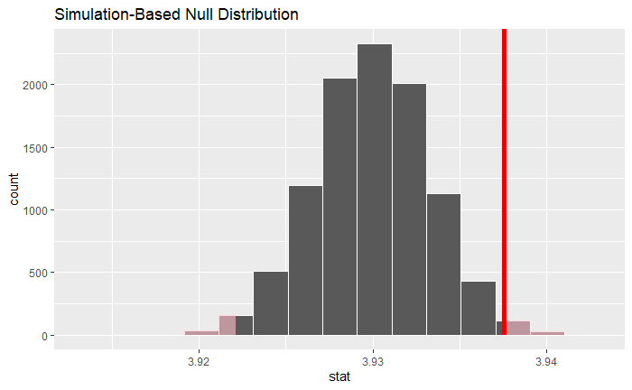

```r
null_distn %>%
  visualise(n = 30) +
  shade_p_value(obs_stat = observed_stat, direction = "both")
```

```r
observed_stat
```

| mean_rating |
| --- |
| 3.937568 |

```r
NA
```

```r
p_value <- null_distn %>%
  get_p_value(obs_stat = observed_stat, direction = "both")

p_value
```

| p_value |
| --- |
| 0.017 |

```r
NA
```

What does the p-value mean?

> How likely is it to see a result as extreme as your observed result, if the null hypothesis is true?

Our observed stat of 3.937 is significantly different from our null stat of 3.93, at an alpha level of 0.05, we therefore find evidence in support of the alternative hypothesis.

## Session 2 - One-sample hypothesis tests

### Learning objectives

- perform a one-sample hypothesis test for proportions using computational methods
- Interpret results of a one-sample hypothesis test for proportion using computational methods

> Question

Does the proportion of books in the Goodreads database that lack text review differ significantly from 7%?

```r
books_tidy %>%
  group_by(text_reviews_count) %>%
  summarise(prop = n() / nrow(books_tidy)) %>%
  filter(text_reviews_count == 0)
```

| text_reviews_count | prop |
| --- | --- |
| 0 | 0.06455132 |

```r
NA
```

Null hypothesis: average proportion of no review books = 7%
$$H_0: \pi_{no\ reviews} = 7\%$$

Alternative hypothesis: average proportion of no review books =/= 7%
$$H_1: \pi_{no\ reviews} \neq 7\%$$

```r
books_tidy_prop <- books_tidy %>%
  mutate(has_no_reviews = text_reviews_count == 0)

mean(books_tidy_prop$has_no_reviews)
```

```
[1] 0.06455132
```

```r
null_distribution <- books_tidy_prop %>%
  specify(response = has_no_reviews, success = "TRUE") %>%
  hypothesise(null = "point", p = 0.07) %>%
  generate(reps = 5000, type = "draw") %>%
  calculate(stat = "prop")

null_distribution
```

```
Response: has_no_reviews (factor)
Null Hypothesis: point
```

| replicate | stat |
| --- | --- |
| 1 | 0.07218838 |
| 2 | 0.07327939 |
| 3 | 0.06746068 |
| 4 | 0.07146104 |
| 5 | 0.07137012 |
| 6 | 0.07064279 |
| 7 | 0.06927903 |
| 8 | 0.07555232 |
| 9 | 0.06964269 |
| 10 | 0.06991545 |

[output cut: 990 more lines]

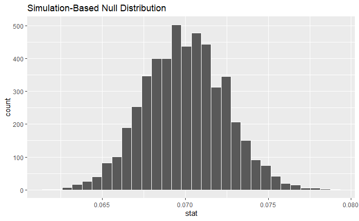

```r
null_distribution %>%
  visualise(bins = 30)
```

```r
observed_stat <- books_tidy_prop %>%
  specify(response = has_no_reviews, success = "TRUE") %>%
  calculate(stat = "prop")

observed_stat
```

```
Response: has_no_reviews (factor)
```

| stat |
| --- |
| 0.06455132 |

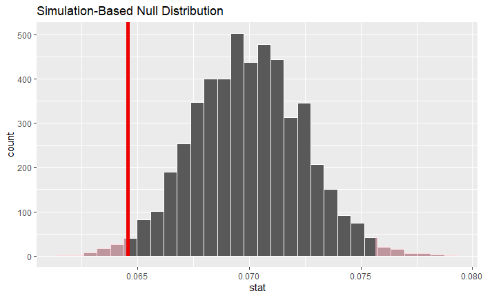

```r
null_distribution %>%
  visualise(bins = 30) +
  shade_p_value(obs_stat = observed_stat, direction = "both")
```

```r
p_value <- null_distribution %>%
  get_p_value(obs_stat = observed_stat, direction = "both")

p_value
```

| p_value |
| --- |
| 0.0244 |

## Session 3 - Two-sample hypothesis tests

```r
nice <- read_csv("data/nice.csv")
algarve <- read_csv("data/algarve.csv")
corfu <- read_csv("data/corfu.csv")
florence <- read_csv("data/florence.csv")
```

## Independent samples

Remember *independent* means the observations are not associated with each other

> Hypotheses

$$H_0: \mu_{algarve} = \mu_{nice}\\
H_1: \mu_{algarve} > \mu_{nice}$$

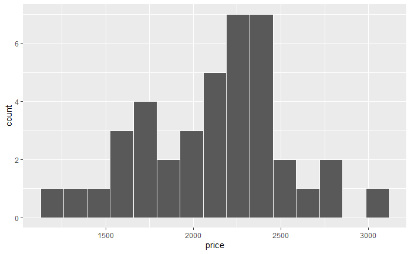

```r
apart_prices <- bind_rows(nice = nice,
                          algarve = algarve,
                          .id = "location")

price_distribution_algarve <- apart_prices %>%
  filter(location == "algarve") %>%
  ggplot(aes(price)) +
  geom_histogram(col = "white", bins = 15)

price_distribution_nice <- apart_prices %>%
  filter(location == "nice") %>%
  ggplot(aes(price)) +
  geom_histogram(col = "white", bins = 15)

price_distribution <- apart_prices %>%
  ggplot(aes(x = location, y = price)) +
  geom_boxplot()


price_distribution_algarve
```

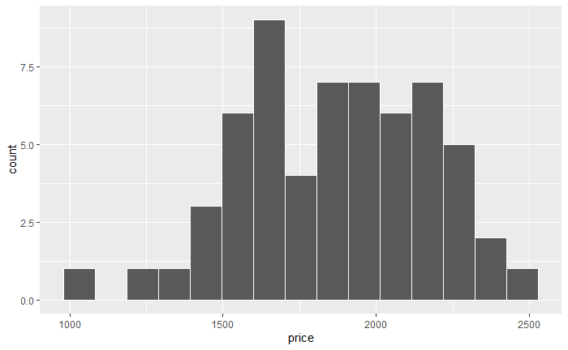

```r
price_distribution_nice
```

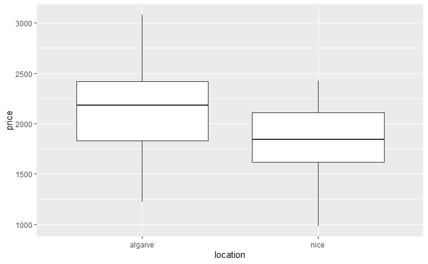

```r
price_distribution
```

```r
null_distribution <- apart_prices %>%
  specify(response = price, explanatory = location) %>%
  hypothesise(null = "independence") %>%
  generate(reps = 10000, type = "permute") %>%
  calculate(stat = "diff in means", order = c("algarve", "nice"))

null_distribution
```

```
Response: price (numeric)
Explanatory: location (factor)
Null Hypothesis: independence
```

| replicate | stat |
| --- | --- |
| 1 | 60.8583333 |
| 2 | -53.6000000 |
| 3 | -49.3083333 |
| 4 | -127.0166667 |
| 5 | 110.6916667 |
| 6 | 22.3166667 |
| 7 | -137.3500000 |
| 8 | 95.1500000 |
| 9 | -1.2666667 |
| 10 | -42.7250000 |

[output cut: 990 more lines]

```r
observed_stat <- apart_prices %>%
  specify(response = price, explanatory = location) %>%
  calculate(stat = "diff in means", order = c("algarve", "nice"))


observed_stat
```

```
Response: price (numeric)
Explanatory: location (factor)
```

| stat |
| --- |
| 251.4 |

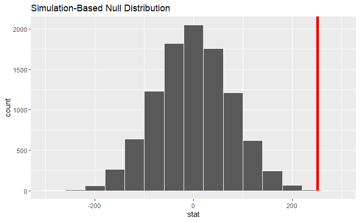

```r
null_distribution %>%
  visualise() +
  shade_p_value(obs_stat = observed_stat, direction = "right")
```

```r
p_value <- null_distribution %>%
  get_p_value(obs_stat = observed_stat, direction = "right")

p_value
```

| p_value |
| --- |
| 2e-04 |

```r
NA
```

# Task

alpha = 0.05 left sided test

$$H_0: \mu_{florence} = \mu_{corfu}\\
H_1: \mu_{florence} < \mu_{corfu}$$

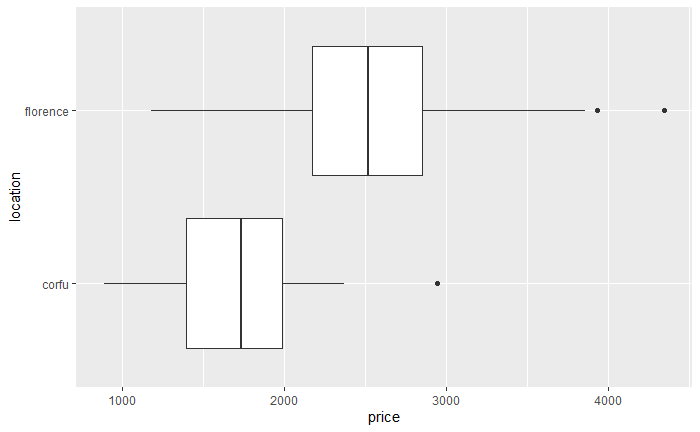

```r
apart_prices <- bind_rows(corfu = corfu,
                          florence = florence,
                          .id = "location")

apart_prices %>%
  ggplot(aes(price, location)) +
  geom_boxplot()
```

```r
null_distribution <- apart_prices %>%
  specify(response = price, explanatory = location) %>%
  hypothesise(null = "independence") %>%
  generate(reps = 10000, type = "permute") %>%
  calculate(stat = "diff in means", order = c("corfu", "florence"))

null_distribution
```

```
Response: price (numeric)
Explanatory: location (factor)
Null Hypothesis: independence
```

| replicate | stat |
| --- | --- |
| 1 | 62.90329670 |
| 2 | -59.96153846 |
| 3 | 10.56483516 |
| 4 | 28.30769231 |
| 5 | -197.39450549 |
| 6 | 70.55824176 |
| 7 | -10.79780220 |
| 8 | -124.70219780 |
| 9 | -117.49230769 |
| 10 | 188.26043956 |

[output cut: 990 more lines]

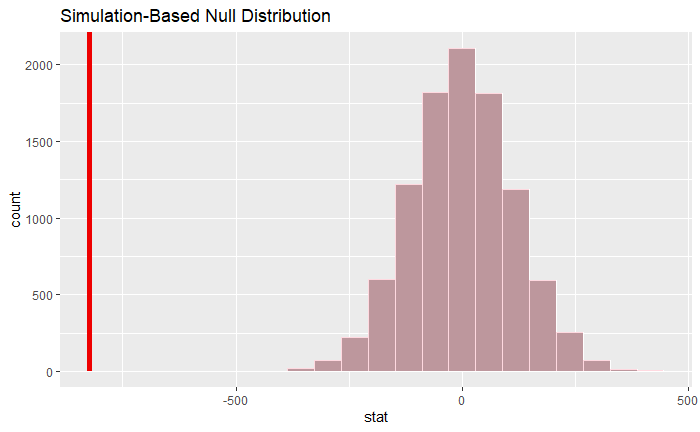

```r
observed_stat <- apart_prices %>%
  specify(response = price, explanatory = location) %>%
  calculate(stat = "diff in means", order = c("corfu", "florence"))

null_distribution %>%
  visualise() +
  shade_p_value(obs_stat = observed_stat, direction = "right")
```

```r
p_value <- null_distribution %>%
  get_p_value(obs_stat = observed_stat, direction = "right")

p_value
```

| p_value |
| --- |
| 1 |

```r
NA
```

## Infer procedure

1. Calculate the *observed* statistic
   1. Create *“flag”* column if necessary
   2. Specify the *response* variable
   3. Calculate the required *stat* e.g. prop / mean
2. Generate the *null distribution*
   1. Specify the *response*
   2. Indicate the *hypothesis* What type of hypothesis (e.g. point) Specify the proportion p (the observed stat)
   3. Generate the *null distribution*
   4. Calculate the *stat* of interest
3. *Visualize* the resut Shade p-value region
4. Extract the *p-value*

### Paired samples (aka dependent)

```r
textbooks <- read_csv("data/ucla_textbooks_f18.csv")
```

> Is there a significant difference on average between the prices for *new texts* offered by the *campus bookstore* vs the prices available for the same texts on *Amazon*?

$$H_0: \mu_{diff\_new} = 0\\
H_1: \mu_{diff\_new} \neq 0$$

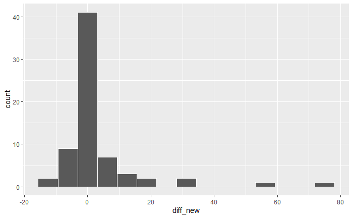

```r
books_diff <- textbooks %>%
  mutate(diff_new = bookstore_new - amazon_new) %>%
  filter(!is.na(diff_new))

books_diff %>%
  ggplot(aes(x = diff_new)) +
  geom_histogram(bins = 15, col = "white")
```

```r
null_distribution <- books_diff %>%
  specify(response = diff_new) %>%
  hypothesise(null = "point", mu = 0) %>%
  generate(reps = 10000, type = "bootstrap") %>%
  calculate(stat = "mean")

null_distribution
```

```
Response: diff_new (numeric)
Null Hypothesis: point
```

| replicate | stat |
| --- | --- |
| 1 | 0.0094117647 |
| 2 | -0.4161764706 |
| 3 | 1.2061764706 |
| 4 | -1.2372058824 |
| 5 | 0.0130882353 |
| 6 | 1.4936764706 |
| 7 | 0.0120588235 |
| 8 | -0.9508823529 |
| 9 | 0.5891176471 |
| 10 | 2.0932352941 |

[output cut: 990 more lines]

```r
observed_stat <- books_diff %>%
  specify(response = diff_new) %>%
  calculate(stat = "mean")

observed_stat
```

```
Response: diff_new (numeric)
```

| stat |
| --- |
| 3.583235 |

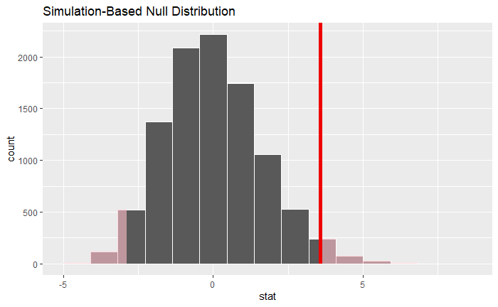

```r
null_distribution %>%
  visualise() +
  shade_p_value(observed_stat, direction = "both")
```

```r
p_value <- null_distribution %>%
  get_p_value(obs_stat = observed_stat, direction = "both")

p_value
```

| p_value |
| --- |
| 0.043 |

```r
NA
```

# Task

Q: On average are the prices of used course texts *lower on Amazon* than at the campus bookstore?

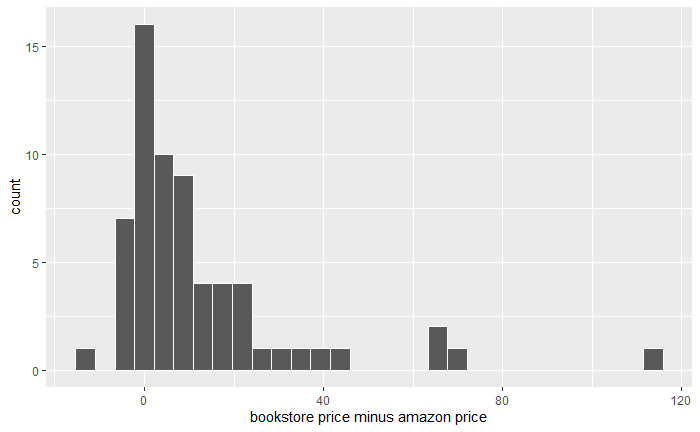

```r
books_diff_used <- textbooks %>%
  mutate(diff_used = bookstore_used - amazon_used) %>%
  filter(!is.na(diff_used))

books_diff_used %>%
  ggplot(aes(diff_used)) +
  geom_histogram(col = "white") +
  labs(x = "bookstore price minus amazon price")
```

```r
observed_stat <- books_diff_used %>%
  specify(response = diff_used) %>%
  calculate(stat = "mean")

observed_stat
```

```
Response: diff_used (numeric)
```

| stat |
| --- |
| 12.16391 |

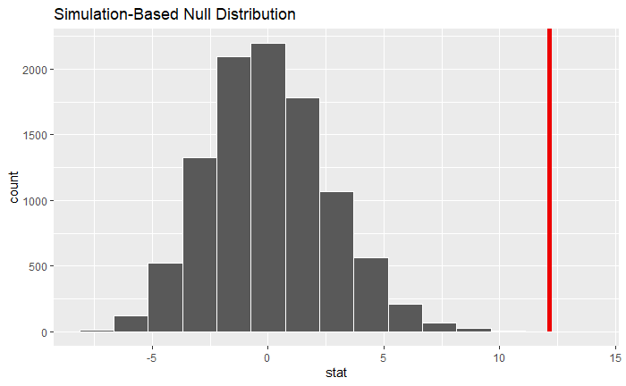

```r
null_distribution <- books_diff_used %>%
  specify(response = diff_used) %>%
  hypothesise(null = "point", mu = 0) %>%
  generate(reps = 10000, type = "bootstrap") %>%
  calculate(stat = "mean")

null_distribution %>%
  visualise() +
  shade_p_value(observed_stat, direction = "right")
```

```r
p_value <- null_distribution %>%
  get_p_value(observed_stat, direction = "right")

p_value
```

| p_value |
| --- |
| 1e-04 |

```r
NA
```